# Exploring Data Analysis with R

## Problem 1–Exploring Vegas Hotel Dataset

### 1.Explore the overall structure of the dataset using str().

```r
directory <- getwd()
lasvegas <- read.csv("vegashotels.csv", sep = ';')
str(lasvegas)
```

```
'data.frame':   504 obs. of  20 variables:
 $ User.country     : Factor w/ 48 levels "Australia","Belgium",..: 48 48 48 46 4 4 46 48 18 4 ...
 $ Nr..reviews      : int  11 119 36 14 5 31 45 2 24 12 ...
 $ Nr..hotel.reviews: int  4 21 9 7 5 8 12 1 3 7 ...
 $ Helpful.votes    : int  13 75 25 14 2 27 46 4 8 11 ...
 $ Score            : int  5 3 5 4 4 3 4 4 4 3 ...
 $ Period.of.stay   : Factor w/ 4 levels "Dec-Feb","Jun-Aug",..: 1 1 3 3 3 3 3 3 3 3 ...
 $ Traveler.type    : Factor w/ 5 levels "Business","Couples",..: 4 1 3 4 5 2 2 3 4 3 ...
 $ Pool             : Factor w/ 2 levels "NO","YES": 1 1 1 1 1 1 1 1 1 1 ...
 $ Gym              : Factor w/ 2 levels "NO","YES": 2 2 2 2 2 2 2 2 2 2 ...
 $ Tennis.court     : Factor w/ 2 levels "NO","YES": 1 1 1 1 1 1 1 1 1 1 ...
 $ Spa              : Factor w/ 2 levels "NO","YES": 1 1 1 1 1 1 1 1 1 1 ...
 $ Casino           : Factor w/ 2 levels "NO","YES": 2 2 2 2 2 2 2 2 2 2 ...
 $ Free.internet    : Factor w/ 2 levels "NO","YES": 2 2 2 2 2 2 2 2 2 2 ...
 $ Hotel.name       : Factor w/ 21 levels "Bellagio Las Vegas",..: 3 3 3 3 3 3 3 3 3 3 ...
 $ Hotel.stars      : Factor w/ 5 levels "3","3,5","4",..: 1 1 1 1 1 1 1 1 1 1 ...
 $ Nr..rooms        : int  3773 3773 3773 3773 3773 3773 3773 3773 3773 3773 ...
 $ User.continent   : Factor w/ 6 levels "Africa","Asia",..: 4 4 4 3 4 4 3 4 2 4 ...
 $ Member.years     : int  9 3 2 6 7 2 4 0 3 5 ...
 $ Review.month     : Factor w/ 12 levels "April","August",..: 5 5 4 4 8 8 1 1 9 9 ...
 $ Review.weekday   : Factor w/ 7 levels "Friday","Monday",..: 5 1 3 1 6 6 1 6 3 6 ...
```

### Use summary to get a summary statistics of each variable. Does any of the variables have missing values?

```r
summary(lasvegas)
```

```
    User.country  Nr..reviews     Nr..hotel.reviews Helpful.votes
 USA      :217   Min.   :  1.00   Min.   :  0.00    Min.   :  0.00
 UK       : 72   1st Qu.: 12.00   1st Qu.:  5.00    1st Qu.:  8.00
 Canada   : 65   Median : 23.50   Median :  9.00    Median : 16.00
 Australia: 36   Mean   : 48.13   Mean   : 16.02    Mean   : 31.75
 Ireland  : 13   3rd Qu.: 54.25   3rd Qu.: 18.00    3rd Qu.: 35.00
 India    : 11   Max.   :775.00   Max.   :263.00    Max.   :365.00
 (Other)  : 90
     Score       Period.of.stay  Traveler.type  Pool      Gym
 Min.   :1.000   Dec-Feb:124    Business: 74   NO : 24   NO : 24
 1st Qu.:4.000   Jun-Aug:126    Couples :214   YES:480   YES:480
 Median :4.000   Mar-May:128    Families:110
 Mean   :4.123   Sep-Nov:126    Friends : 82
 3rd Qu.:5.000                  Solo    : 24
 Max.   :5.000

 Tennis.court  Spa      Casino    Free.internet
 NO :384      NO :120   NO : 48   NO : 24
 YES:120      YES:384   YES:456   YES:480





                                  Hotel.name  Hotel.stars   Nr..rooms
 Bellagio Las Vegas                    : 24   3  : 96     Min.   : 188
 Caesars Palace                        : 24   3,5: 72     1st Qu.: 826
 Circus Circus Hotel & Casino Las Vegas: 24   4  :120     Median :2700
 Encore at wynn Las Vegas              : 24   4,5: 24     Mean   :2196
 Excalibur Hotel & Casino              : 24   5  :192     3rd Qu.:3025
 Hilton Grand Vacations at the Flamingo: 24               Max.   :4027
 (Other)                               :360
       User.continent  Member.years          Review.month   Review.weekday
 Africa       :  7    Min.   :-1806.0000   April   : 42   Friday   :65
 Asia         : 36    1st Qu.:    2.0000   August  : 42   Monday   :74
 Europe       :118    Median :    4.0000   December: 42   Saturday :61
 North America:295    Mean   :    0.7679   February: 42   Sunday   :77
 Oceania      : 41    3rd Qu.:    6.0000   January : 42   Thursday :62
 South America:  7    Max.   :   13.0000   July    : 42   Tuesday  :80
                                           (Other) :252   Wednesday:85
```

### Draw a histogram of the score variable. Describe what you see in the histogram.

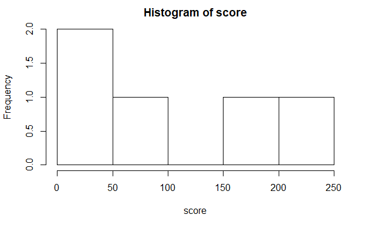

```r
lasvegas <- read.csv("vegashotels.csv", sep = ';')
score <- table(lasvegas$Score)
hist(score)
```

## Find the mode of “Score”

```r
# Create the function.
getmode <- function(m) {
   uniqv <- unique(m)
   uniqv[which.max(tabulate(match(m, uniqv)))]
}
# Create the vector with numbers.
m <- lasvegas$Score
# Calculate the mode using the user function.
ModeofScore <- getmode(m)
print(ModeofScore)
```

```
[1] 5
```

## Use the “quantile” function to get the quantiles for score. What is the median of score?

```r
q <- quantile(lasvegas$Score)
print(q)
```

```
  0%  25%  50%  75% 100%
   1    4    4    5    5
```

```r
p <-median(lasvegas$Score)
print(p)
```

```
[1] 4
```

## Use the ifelse function (You can get help on the syntax of this function in R by typing ?ifelse) to create a factor variable “sentiment” which takes the value “positive” if score is 4 or 5 and “negative” otherwise. You can use the method “factor” to create a factor from a character vector.

```r
lasvegas <- read.csv("vegashotels.csv", sep = ';')
ses<- ifelse((lasvegas$Score == 4) | (lasvegas$Score == 5),"Positive","Negative")
ses.f <- factor(ses, levels = c("Positive","Negative"))
is.factor(ses.f)
```

```
[1] TRUE
```

```r
lasvegas$Sentiment<-ses.f
lasvegas$Sentiment
```

```
  [1] Positive Negative Positive Positive Positive Negative Positive
  [8] Positive Positive Negative Negative Negative Negative Negative
 [15] Negative Positive Negative Positive Negative Negative Positive
 [22] Negative Positive Negative Positive Positive Positive Negative
 [29] Positive Positive Positive Negative Negative Negative Positive
 [36] Negative Positive Positive Positive Negative Negative Negative
 [43] Negative Positive Positive Positive Positive Negative Negative
 [50] Positive Negative Positive Negative Positive Positive Negative
 [57] Positive Positive Positive Positive Positive Negative Negative
 [64] Negative Negative Positive Negative Negative Positive Negative
 [71] Negative Positive Negative Positive Positive Positive Positive
 [78] Positive Positive Negative Negative Positive Negative Positive
 [85] Positive Positive Positive Positive Negative Positive Positive
 [92] Negative Positive Positive Positive Positive Positive Positive
 [99] Negative Negative Positive Positive Positive Positive Positive
```

[output cut: 58 more lines]

## Take a summary of “sentiment” to make sure that the frequencies of “positive” and “negative” categories are consistent with the frequency of the values in Score (e.g., the frequency for the “positive” sentiment should be equal to the combined frequency of 4 and 5 for the Score)

```r
lasvegas <- read.csv("vegashotels.csv", sep = ';')
ses<- ifelse((lasvegas$Score == 4) | (lasvegas$Score == 5),"Positive","Negative")
ses.f <- factor(ses, levels = c("Positive","Negative"))
is.factor(ses.f)
```

```
[1] TRUE
```

```r
lasvegas$Sentiment<-ses.f
summary(lasvegas$Sentiment)
```

```
Positive Negative
     391      113
```

```r
summary(lasvegas$Score == 4 |lasvegas$Score == 5)
```

```
   Mode   FALSE    TRUE
logical     113     391
```

## Use chisquare test to determine if sentiment is associated with any of the variables: “Pool”, “Gym”,“Free.Internet”, “Period.of.Stay”, “traverler.type”“, and”hotel.stars" (Assume the significance level alpha=0.01). Which of these variables are associated with sentiment?

```r
lasvegas <- read.csv("vegashotels.csv", sep = ';')
ses<- ifelse((lasvegas$Score == 4) | (lasvegas$Score == 5),"Positive","Negative")
ses.f <- factor(ses, levels = c("Positive","Negative"))
is.factor(ses.f)
```

```
[1] TRUE
```

```r
ses.f
```

```
  [1] Positive Negative Positive Positive Positive Negative Positive
  [8] Positive Positive Negative Negative Negative Negative Negative
 [15] Negative Positive Negative Positive Negative Negative Positive
 [22] Negative Positive Negative Positive Positive Positive Negative
 [29] Positive Positive Positive Negative Negative Negative Positive
 [36] Negative Positive Positive Positive Negative Negative Negative
 [43] Negative Positive Positive Positive Positive Negative Negative
 [50] Positive Negative Positive Negative Positive Positive Negative
 [57] Positive Positive Positive Positive Positive Negative Negative
 [64] Negative Negative Positive Negative Negative Positive Negative
 [71] Negative Positive Negative Positive Positive Positive Positive
 [78] Positive Positive Negative Negative Positive Negative Positive
 [85] Positive Positive Positive Positive Negative Positive Positive
 [92] Negative Positive Positive Positive Positive Positive Positive
 [99] Negative Negative Positive Positive Positive Positive Positive
```

[output cut: 58 more lines]

```r
lasvegas$Sentiment<-ses.f
# Load the library.
library("MASS")
# Perform the Chi-Square test.
chisq <- chisq.test(lasvegas$Sentiment,lasvegas$Gym)
```

[output not shown]

# Exploring California Housing Dataset

## Explore the structure of dataset using str function. How many numerical and categorical attributes are there in the dataset.

```r
directory <- getwd()
housing <- read.csv("housing.csv", sep = ',')
str(housing)
```

```
'data.frame':   20640 obs. of  10 variables:
 $ longitude         : num  -122 -122 -122 -122 -122 ...
 $ latitude          : num  37.9 37.9 37.9 37.9 37.9 ...
 $ housing_median_age: num  41 21 52 52 52 52 52 52 42 52 ...
 $ total_rooms       : num  880 7099 1467 1274 1627 ...
 $ total_bedrooms    : num  129 1106 190 235 280 ...
 $ population        : num  322 2401 496 558 565 ...
 $ households        : num  126 1138 177 219 259 ...
 $ median_income     : num  8.33 8.3 7.26 5.64 3.85 ...
 $ median_house_value: num  452600 358500 352100 341300 342200 ...
 $ ocean_proximity   : Factor w/ 5 levels "<1H OCEAN","INLAND",..: 4 4 4 4 4 4 4 4 4 4 ...
```

## Take a summary statistics of the dataset. Does any of the variables have missing values?

```r
##To  find the Summary of the Dataset
summary(housing)
```

```
   longitude         latitude     housing_median_age  total_rooms
 Min.   :-124.3   Min.   :32.54   Min.   : 1.00      Min.   :    2
 1st Qu.:-121.8   1st Qu.:33.93   1st Qu.:18.00      1st Qu.: 1448
 Median :-118.5   Median :34.26   Median :29.00      Median : 2127
 Mean   :-119.6   Mean   :35.63   Mean   :28.64      Mean   : 2636
 3rd Qu.:-118.0   3rd Qu.:37.71   3rd Qu.:37.00      3rd Qu.: 3148
 Max.   :-114.3   Max.   :41.95   Max.   :52.00      Max.   :39320

 total_bedrooms     population      households     median_income
 Min.   :   1.0   Min.   :    3   Min.   :   1.0   Min.   : 0.4999
 1st Qu.: 296.0   1st Qu.:  787   1st Qu.: 280.0   1st Qu.: 2.5634
 Median : 435.0   Median : 1166   Median : 409.0   Median : 3.5348
 Mean   : 537.9   Mean   : 1425   Mean   : 499.5   Mean   : 3.8707
 3rd Qu.: 647.0   3rd Qu.: 1725   3rd Qu.: 605.0   3rd Qu.: 4.7432
 Max.   :6445.0   Max.   :35682   Max.   :6082.0   Max.   :15.0001
 NA's   :207
 median_house_value   ocean_proximity
 Min.   : 14999     <1H OCEAN :9136
 1st Qu.:119600     INLAND    :6551
 Median :179700     ISLAND    :   5
 Mean   :206856     NEAR BAY  :2290
 3rd Qu.:264725     NEAR OCEAN:2658
 Max.   :500001
```

```r
## To find the missing values in the dataset
which(is.na(housing$total_bedrooms))
```

```
  [1]   291   342   539   564   697   739  1098  1351  1457  1494  1607
 [12]  2029  2116  2302  2324  2335  2352  2413  2421  2579  2609  2648
 [23]  2827  3025  3329  3355  3377  3483  3486  3530  3722  3779  3913
 [34]  3922  3959  4044  4047  4187  4280  4310  4392  4448  4497  4592
 [45]  4601  4630  4668  4692  4739  4744  4745  4768  4853  5060  5217
 [56]  5223  5237  5655  5666  5679  5724  5752  5991  6053  6069  6221
 [67]  6242  6254  6299  6422  6542  6591  6815  6836  6963  7098  7114
 [78]  7169  7192  7229  7317  7331  7548  7655  7669  7764  7807  8338
 [89]  8384  8531  8916  9150  9572  9621  9623  9815  9846  9878  9943
[100]  9971 10034 10217 10237 10386 10390 10429 10496 10762 10886 10916
[111] 11097 11312 11352 11442 11450 11513 11742 12102 12415 12571 12810
[122] 13016 13070 13312 13333 13337 13598 13657 13707 13926 13933 13934
[133] 14016 14153 14174 14308 14332 14387 14463 14522 14642 14931 14971
[144] 14987 15031 15061 15119 15138 15398 15480 15608 15664 15891 15976
[155] 16026 16039 16105 16106 16331 16758 16880 16881 16886 17042 17199
[166] 17203 17640 17826 17841 17924 17929 17974 18178 18247 18262 18333
[177] 18347 18467 18787 18874 18915 19061 19072 19123 19151 19253 19333
[188] 19392 19403 19486 19560 19608 19639 19767 19819 19834 19891 19933
[199] 19960 20047 20070 20126 20268 20269 20373 20461 20485
```

## Remove the rows with missing values. You can use either “complete.cases” function or “na.omit” function for this purpose. Run ?complete.cases and ?na.omit in R to get help on these functions and to see some examples.

```r
na.omit(housing$total_bedrooms)
```

```
   [1]  129 1106  190  235  280  213  489  687  665  707  434  752  474
  [14]  191  626  283  347  293  455  298  184  367  541  337  437  123
  [27]  244  421  492  160  447  481  409  366  574  282  432  390  330
  [40]  715  419  311  202  202  311  420  322  312  195  375  453  456
  [53]  853  456  235  243  288  335  341   43  211   29  190  237  182
  [66]  209  354  244  109  644  152  297  204    4  161  462  562  243
  [79]  374  176  289   56   97  164  184  143  451  348   42   78  392
  [92]   87   31  347  623 2477 1331  107 1270 1085 1414 1603  242  701
 [105] 1914  225  482  460  751  855  289 1098 1196  559  428  287 1750
 [118] 1105  399  454  406   54  411  574  365 1048  473  597  674  346
 [131]  490  210  460  788  184  223  271  264  181  534   38  333  436
 [144]  605  535  212  335  465  464  541  339  536  486  229  402  292
 [157]  313  238  365  550  168  510  502  835 1065  792  469  864  492
 [170]  526  188  391  606  647  228  373  398  588  289  420  749  184
 [183]  414  480  299 1344  395  264  431  395  180  376   43  129  237
```

[output cut: 85 more lines]

## Draw a histogram and boxplot of the median_house_value. What can you say about the shape of median_house_value? Is the median_house_value sample positively skewed, symmetric, or negatively skewed?

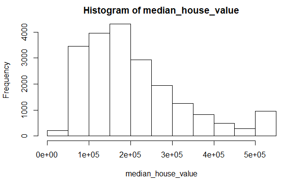

```r
housing <- read.csv("housing.csv", sep = ',')
median_house_value <- housing$median_house_value
hist(median_house_value)
```

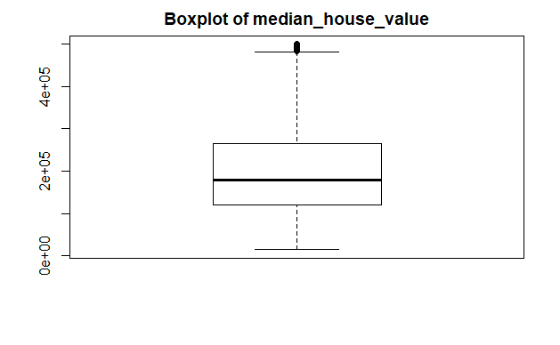

```r
boxplot(housing$median_house_value, main="Boxplot of median_house_value")
```

The histogram of median_House_Value is positively skewed.

## Use Q-Q plot to examine if the distribution of median_house_value is approximately normal?

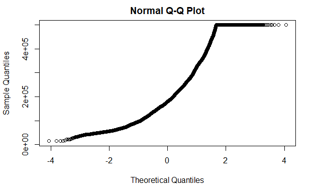

```r
qqnorm(housing$median_house_value)
```

```r
IQR <- IQR(housing$median_house_value)
IQR
```

```
[1] 145125
```

## Use “pairs” and “cor” functions to get a scatter plot and correlation matrix of numerical attributes in the dataset. Does any of the numerical attributes have a linear correlation with median_house_value?

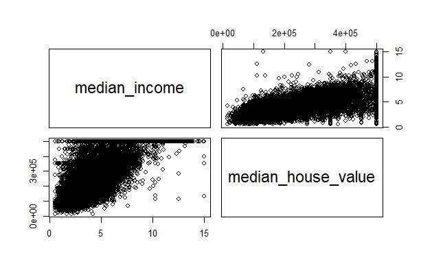

```r
numeric_attributes = housing[,c("median_income","median_house_value")]
pairs(numeric_attributes)
```

```r
cor(numeric_attributes)
```

```
                   median_income median_house_value
median_income          1.0000000          0.6880752
median_house_value     0.6880752          1.0000000
```

The median income is correlated with median_house_value in the housing dataset.

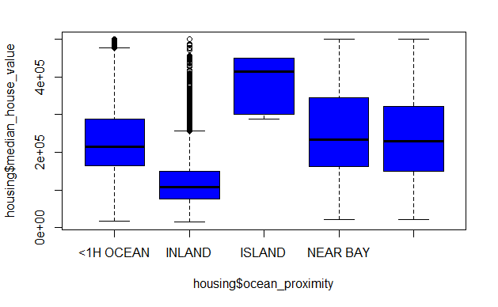

```r
plot(housing$median_house_value ~ housing$ocean_proximity, col="blue")
```

Yes, there are differences between the mean of different ocean proximity levels.The mean of the Island is highest amongst all and the mean of inland is the lowest.

## Use ifelse function to create a new factor variable “Is_Inland” which takes the value “Yes” if the ocean_proximity is “Inland” and No" otherwise.

```r
housing <- read.csv("housing.csv", sep = ',')
Is_Inland <- ifelse((housing$ocean_proximity == "INLAND"),"Yes","No")
Is_Inland.f <- factor(Is_Inland, levels = c("Yes","No"))
is.factor(Is_Inland.f)
```

```
[1] TRUE
```

```r
housing$Is_Inland <- Is_Inland.f
housing$Is_Inland
```

```
   [1] No  No  No  No  No  No  No  No  No  No  No  No  No  No  No  No  No
  [18] No  No  No  No  No  No  No  No  No  No  No  No  No  No  No  No  No
  [35] No  No  No  No  No  No  No  No  No  No  No  No  No  No  No  No  No
  [52] No  No  No  No  No  No  No  No  No  No  No  No  No  No  No  No  No
  [69] No  No  No  No  No  No  No  No  No  No  No  No  No  No  No  No  No
  [86] No  No  No  No  No  No  No  No  No  No  No  No  No  No  No  No  No
 [103] No  No  No  No  No  No  No  No  No  No  No  No  No  No  No  No  No
 [120] No  No  No  No  No  No  No  No  No  No  No  No  No  No  No  No  No
 [137] No  No  No  No  No  No  No  No  No  No  No  No  No  No  No  No  No
 [154] No  No  No  No  No  No  No  No  No  No  No  No  No  No  No  No  No
 [171] No  No  No  No  No  No  No  No  No  No  No  No  No  No  No  No  No
 [188] No  No  No  No  No  No  No  No  No  No  No  No  No  No  No  No  No
 [205] No  No  No  No  No  No  No  No  No  No  No  No  No  No  No  No  No
 [222] No  No  No  No  No  No  No  No  No  No  No  No  No  No  No  No  No
 [239] No  No  No  No  No  No  No  No  No  No  No  No  No  No  No  No  No
```

[output cut: 46 more lines]

```r
x = rnorm(housing$median_house_value)
y = rnorm(housing$Is_Inland)
t.test(x,y)
```

```
    Welch Two Sample t-test

data:  x and y
t = 0.25011, df = 41278, p-value = 0.8025
alternative hypothesis: true difference in means is not equal to 0
95 percent confidence interval:
 -0.01676581  0.02167056
sample estimates:
    mean of x     mean of y
-0.0001481047 -0.0026004786
```